# Variables, escalas de medición y análisis bivariado

Curso de Análisis Exploratorio y Visualización de Datos con R

Profesor Andre Chocó Cedillos

# 1 Concepto de Variable

Las características de los eventos de interés son llamadas en estadística **variables**. Se llaman variables porque pueden tomar diversos valores entre diferentes individuos. Por ejemplo, el peso de una persona es 55 kg mientras otra pesa 70 kg. O en el mismo individuo se puede observar variabilidad en dos diferentes momentos: una persona pesa 55 kg y en otro momento pesó 50 kg.

# 2 Tipos de Variables

A los datos que en su origen son números se los denomina **cuantitativos** o **numéricos**, y a aquellos que describen características (palabras) se los denomina datos **cualitativos** o **categóricos**.

## 2.1 Variables Categóricas (Cualitativas)

Algunas características no son capaces de ser medidas en el sentido en que se miden estatura, peso y edad. Solo pueden categorizarse. Las mediciones hechas sobre variables categóricas transmiten información sobre un **atributo**.

El proceso de medición de estas variables consiste en contar los sujetos o unidades muestrales clasificadas en cada categoría. Los datos resultantes representan frecuencias o proporciones de observaciones dentro de cada grupo o nivel de la variable.

## 2.2 Variables Numéricas (Cuantitativas)

Una **variable numérica** es aquella que puede medirse en el sentido usual. Las mediciones hechas sobre variables cuantitativas transmiten información sobre **cantidad**.

# 3 Escalas de Medición

El nivel de medida de una variable o escala de medición es una clasificación acordada con el fin de describir la naturaleza de la información contenida dentro de los números asignados a los objetos y, por lo tanto, dentro de una variable.

La medición es la **asignación de números a objetos o eventos según un conjunto de reglas**. Las varias escalas de medición resultan del hecho de que la medición puede llevarse a cabo bajo diferentes conjuntos de reglas.

## 3.1 Escala Nominal

La escala de medición más baja es la **escala nominal**. Como su nombre implica, consiste en “nombrar” observaciones o clasificarlas en categorías mutuamente excluyentes y colectivamente exhaustivas.

La escala nominal consiste en variables categóricas cuyas características no presentan ningún orden, y por tanto no provee información alguna de la relación entre las categorías.

**Características:**

- Categorías mutuamente excluyentes
- Colectivamente exhaustivas
- No existe orden entre categorías
- Los números (si se usan) son solo etiquetas

**Ejemplos:**

- Sexo (masculino/femenino)
- Diagnóstico médico
- Grupo sanguíneo (A, B, AB, O)
- Tipo de microorganismo identificado en un urocultivo positivo

Escala Nominal: Estadísticos y Representaciones Gráficas

| Escala de Medición | Estadísticos | Representaciones Gráficas |
| --- | --- | --- |
| Nominales | Frecuencia, Porcentajes | Gráficas de barras |

## 3.2 Escala Ordinal

Cuando las observaciones no solo difieren de categoría a categoría sino que pueden ordenarse según algún criterio, se dice que están medidas en una **escala ordinal**.

Se refiere a una variable categórica cuyas categorías sí pueden ordenarse, aunque estos no son considerados números reales.

**Características:**

- Las categorías pueden ordenarse
- Los miembros de una categoría son considerados menores, peores o más pequeños que los de otra
- La diferencia entre categorías adyacentes no necesariamente es igual

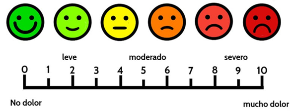

**Figura 1. Escala visual análoga del dolor, un ejemplo de variable ordinal**

**Ejemplos:**

- Estado nutricional (bajo de peso, normal, sobrepeso, obesidad)
- Nivel de dolor (ausente, leve, moderado, severo, insoportable)
- Nivel socioeconómico (bajo, medio, alto)

Escala Ordinal: Estadísticos y Representaciones Gráficas

| Escala de Medición | Estadísticos | Representaciones Gráficas |
| --- | --- | --- |
| Ordinales | Frecuencia, Porcentajes, Mediana y Cuartiles* | Gráficas de barras, Boxplot |

## 3.3 Escala de Intervalo

La **escala de intervalo** es más sofisticada que la nominal u ordinal, ya que con esta escala no solo es posible ordenar mediciones, sino que también se conoce la distancia entre dos mediciones cualesquiera.

Se refiere a números verdaderos, susceptibles de medición que informan qué tan grande o tan pequeña resulta una medida respecto de otra, es decir, las distancias entre puntos sucesivos en la escala son equivalentes.

**Características:**

- Se puede determinar la igualdad de intervalos
- Usa una unidad de distancia
- El punto cero es arbitrario
- No indica ausencia total de la cantidad medida

**Importante**: La escala de intervalo no posee un cero absoluto.

**Ejemplo:**

Temperatura en grados Celsius o Fahrenheit. La unidad de medición es el grado, y el punto de comparación es el “cero grados” elegido arbitrariamente, que no indica falta de calor.

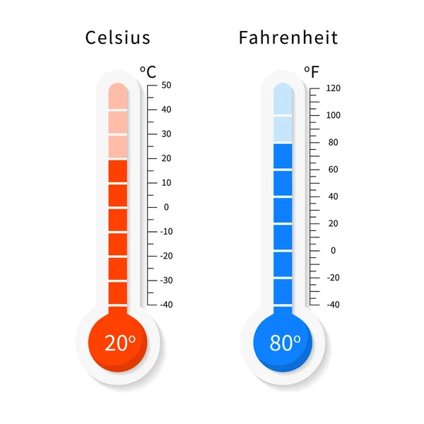

**Figura 2. El cero relativo de las escalas para medir la temperatura**

Escala de Intervalo: Estadísticos y Representaciones Gráficas

| Escala de Medición | Estadísticos | Representaciones Gráficas |
| --- | --- | --- |
| Intervalo | Media y Desviación estándar (Distribución normal), Mediana y Cuartiles (Distribución no normal) | Histograma, Boxplot, QQ-Plot |

## 3.4 Escala de Razón

El nivel más alto de medición es la **escala de razón**. Esta escala se caracteriza por el hecho de que puede determinarse igualdad de razones así como igualdad de intervalos. Fundamental para la escala de razón es un **punto cero verdadero**.

La escala de razón posee todas las características de las escalas anteriores y un cero absoluto.

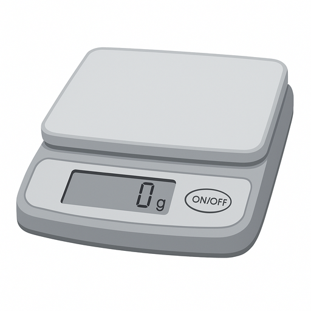

**Figura 3. El cero absoluto: Ausencia de la propiedad a medir**

**Características:**

- Posee un punto cero verdadero
- El cero representa ausencia total de la característica
- Se pueden calcular razones significativas
- Todas las operaciones aritméticas son válidas

**Ejemplos:**

- Peso (0 kg representa ausencia de peso; 80 kg es el doble de 40 kg)
- Estatura (0 cm representa ausencia de estatura)
- Edad (0 años representa el nacimiento)
- Número de hijos
- Concentraciones sanguíneas

| Escala de Medición | Estadísticos | Representaciones Gráficas |
| --- | --- | --- |
| Razón | Media y Desviación estándar (Distribución normal), Mediana y Cuartiles (Distribución no normal) | Histograma, Boxplot, QQ-Plot |

# 4 Jerarquía de las Escalas de Medición

La siguiente tabla refuerza el concepto de jerarquía de las escalas de medición: la escala nominal es la que posee únicamente la propiedad de asignar y clasificar observaciones, mientras que la escala de razón tiene todas las propiedades del resto de las escalas y además las propiedades de poseer un cero absoluto y, en consecuencia, la existencia de cocientes.

Jerarquía y Propiedades de las Escalas de Medición

| Propiedades | Nominal | Ordinal | Intervalo | Razón |
| --- | --- | --- | --- | --- |
| Asigna y clasifica datos | Sí | Sí | Sí | Sí |
| Ordena los datos | No | Sí | Sí | Sí |
| Marca distancia entre datos | No | No | Sí | Sí |
| Tienen significado las diferencias entre los valores | No | No | Sí | Sí |
| Tienen significado el cociente de los valores | No | No | No | Sí |
| Los datos tienen origen (el cero tiene significado) | No | No | No | Sí |

# 5 Sub-escalas de Medición

## 5.1 Dicotómica y Politómica (Escala Nominal)

- **Dicotómica**: Variables con exactamente dos categorías (dos valores posibles)
- **Politómica**: Variables con más de dos categorías (posibilidad de más de dos categorías)

Ejemplos de Sub-escalas en Escala Nominal

| Variable | Tipo | Escala | Sub-escala | Categorías / Unidad de medida |
| --- | --- | --- | --- | --- |
| Sexo | Cualitativa | Nominal | Dicotómica | Masculino, Femenino |
| Enfermedad crónica concomitante | Cualitativa | Nominal | Politómica | Enfermedad renal crónica, Diabetes mellitus, Hipertensión arterial, Hipotiroidismo, Dislipidemia, Ninguna |

## 5.2 Discreta y Continua (Escalas de Intervalo y Razón)

### 5.2.1 Variables Discretas

Una **variable discreta** se caracteriza por intervalos o interrupciones en los valores que puede asumir. Estos intervalos indican la ausencia de valores entre valores particulares que la variable puede asumir.

Las escalas discretas son números que no permiten divisiones decimales. Típicamente resultan del proceso de **contar**.

**Características:**

- Posee intervalos o “saltos” entre valores
- Usualmente representada por números enteros
- Resulta del conteo

**Ejemplos:**

- Número de admisiones hospitalarias diarias (0, 1, 2, 3…)
- Número de dientes cariados, perdidos o empastados
- Número de hijos

### 5.2.2 Variables Continuas

Una **variable continua** no posee los intervalos o interrupciones características de una variable discreta. Puede asumir cualquier valor dentro de un intervalo relevante específico.

Las escalas continuas permiten divisiones decimales. La continuidad está limitada solo por la habilidad de medirla con precisión. Típicamente resultan de la **medición**.

**Características:**

- No posee interrupciones entre valores
- Puede asumir cualquier valor en un intervalo
- Resulta de la medición

**Ejemplos:**

- Estatura (puede ser 170.5 cm, 170.51 cm, 170.512 cm…)
- Peso corporal
- Presión arterial

Ejemplos de Sub-escalas en Escalas de Intervalo y Razón

| Variable | Tipo | Escala | Sub-escala | Unidad de medida |
| --- | --- | --- | --- | --- |
| Calidad de vida | Cuantitativa | Intervalo | Discreta | Puntuaciones |
| Temperatura °C | Cuantitativa | Intervalo | Continua | ° Celsius |
| Número de hijos | Cuantitativa | Razón | Discreta | Conteo |
| Peso | Cuantitativa | Razón | Continua | Kg |

Escala de Razón: Subescalas, Estadísticos y Gráficos

| Subescala | Estadísticos | Gráficos |
| --- | --- | --- |
| Discreta | Mediana y Cuartiles, Frecuencia y Porcentajes | Se prefiere Boxplot a Histograma, Gráfica de barras |
| Continua | Media y Desviación estándar (Distribución normal), Mediana y Cuartiles (Distribución no normal) | Histograma, Boxplot, QQ-Plot |

# 6 Variables Duras y Variables Blandas

## 6.1 Variables Duras

Son aquellas en las cuales existe una **medición objetiva**:

- Al repetirse se obtienen resultados similares (reproducibilidad)
- Generalmente tienen poca posibilidad de influencia externa
- Existen instrumentos precisos de medición
- Baja variabilidad interobservador

**Ejemplos**: peso corporal, estatura, presión arterial (con instrumentos calibrados), concentración de glucosa en sangre

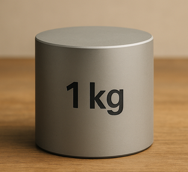

**Figura 4. Peso: Ejemplo de variable dura**

## 6.2 Variables Blandas

Son aquellas que **no son objetivas** o que tienen un grado alto de subjetividad:

- No hay instrumentos de medición estandarizados
- No hay necesariamente repetibilidad cuando se hacen varias mediciones en condiciones similares
- Puede haber influencia externa
- Alta variabilidad interobservador

**Ejemplos**: calidad de vida, percepción del dolor, nivel de satisfacción del paciente, depresión (escalas subjetivas)

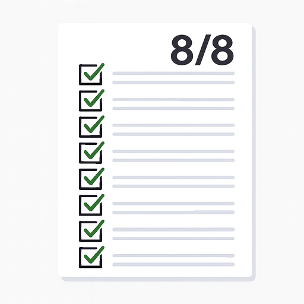

**Figura 5. Conocimiento: Ejemplo de variable blanda**

Comparación entre Variables Duras y Variables Blandas

| Característica | Variables Duras | Variables Blandas |
| --- | --- | --- |
| Objetividad | Alta | Baja |
| Instrumentos | Precisos y calibrados | No estandarizados |
| Reproducibilidad | Alta | Baja |
| Influencia externa | Baja | Alta |
| Variabilidad interobservador | Baja | Alta |

# 7 Análisis Bivariado

El análisis bivariado permite examinar la relación entre dos variables. Dependiendo del tipo de variables involucradas (categóricas, numéricas o una combinación), se utilizan diferentes técnicas estadísticas, tablas y gráficas para explorar, describir e interpretar esta relación.

## 7.1 Variables Independientes y Dependientes

Cuando se hacen relaciones, contrastes o comparaciones de variables se debe diferenciar entre variable independiente y dependiente:

- **Variable independiente**: Aquella que produce modificaciones en otra variable con la cual está relacionada. También se denomina **variable causal**.
- **Variable dependiente**: Experimenta modificaciones siempre que la variable independiente cambia de valor o modalidad. También recibe el nombre de **variable efecto** o **variable respuesta**.

**Importante**: En cualquier tipo de investigación, la variable respuesta no se puede manipular sino sólo medir.

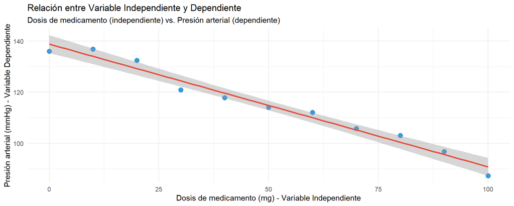

## 7.2 Tamaño del Efecto

El **tamaño del efecto** es una medida cuantitativa de la magnitud de la diferencia, asociación o correlación entre variables. A diferencia del valor p, que indica si una relación es estadísticamente significativa, el tamaño del efecto describe la **importancia práctica o real** de esa relación.

El tamaño del efecto permite: - Comparar resultados entre diferentes estudios - Cuantificar la fuerza de la relación entre variables - Evaluar si una diferencia es prácticamente relevante, independientemente de la significancia estadística

## 7.3 Tipos de Análisis Bivariado según Tipo de Variables

## 7.4 Análisis de Asociación: Ambas Variables son Categóricas

El análisis de asociación se utiliza cuando ambas variables de interés son categóricas (nominales u ordinales). El objetivo es determinar si existe una relación entre las categorías de una variable y las categorías de la otra variable.

Tipos de Análisis Bivariado según Tipo de Variables

[output not shown]

## 7.5 Análisis de Diferencia: Variable Numérica y Variable Categórica

El análisis de diferencia se utiliza cuando se compara una variable numérica entre dos o más grupos definidos por una variable categórica. El objetivo es determinar si existen diferencias significativas en los valores de la variable numérica entre los grupos.

## 7.6 Resumen de Técnicas de Análisis Bivariado

Técnicas de Análisis Bivariado: Estadísticos, Tamaño del Efecto y Gráficas

| Relación | Tablas | Estadísticos | Tamaño del Efecto | Gráficas |
| --- | --- | --- | --- | --- |
| Variables categóricas - Variables categóricas | De contingencia | Frecuencia, Porcentaje | Coeficiente de contingencia, V de Cramer, Phi de Cramer, Tau-B de Kendall | De asociación |
| Variables categóricas - Variables numéricas | De diferencia | Diferencia de promedios, desviación estándar de las diferencias; mediana de las diferencias | D Cohen, Eta2, correlación biserida de rangos | Boxplot, barras de error |
| Variables numéricas - Variables numéricas |  | Coeficiente de correlación de Pearson (Distribución normal), Coeficiente de correlación de Spearman (Distribución no normal) | Coeficiente de correlación de Pearson, Coeficiente de correlación de Spearman | Dispersión |